# Exercícios práticos em Ecologia de Populações e Comunidade Vegetais

Disciplina BIE-0320, Graduação em Biologia, IB-USP

# Apresentação

Neste site guardo alguns exercícios práticos em R que desenvolvi para disciplina Ecologia de Populações e Comunidades Vegetais, do curso de Graduação em Ciências Biológicas da USP.

Para outros tutoriais em ecologia, veja o [Portal EcoVirtual](http://ecovirtual.ib.usp.br/).

# Estrutura de populações

Um dos fenômenos mais estudados em ecologia são padrões, ou estruturas. Alguns exemplos de estrutura: * *Estrutura de tamanhos*: a proporção de indivíduos de uma população de árvores em classes de diâmetro; * *Padrão de abundâncias*: proporção, ou número de espécies em classes de abundâncias (por exemplo, raras x abundantes); * *Estrutura espacial*: distribuição de plantas numa área.

Podemos pensar nos padrões como cenas de um filme, que se sucedem, obedecendo a dinâmica, que é o roteiro do filme. Ao identificar padrões, podemos entender muito da dinâmica que os gerou.

Neste exercício prático, vamos demonstrar isso analisando estrutura espaciais.

## Estrutura espacial

A distribuição das plantas adultas no espaço é um testemunho dos processos de dispersão de propágulos, estabelecimento de jovens, e sua sobrevivência. Por isso, a Ecologia Vegetal desenvolveu várias técnicas para identificar os **padrões de distribuição espacial de plantas**, que dão pistas importantes sobre os processos ecológicos que geraram estes padrões. Nesta prática, você vai conhecer uma destas técnicas, que é a análise de padrões de pontos no espaço (*Point pattern analysis*).

Aqui estão os links para os três roteiros desta prática, siga-os nesta ordem:

1. Simulação de padrões de pontos no espaço
2. O índice L de Ripley
3. Modelos de distribuição de pontos no espaço

# Estrutura de Comunidades

Três aspectos essenciais da estrutura das comunidades são a riqueza de espécies, a composição de espécies e suas abundâncias. Um dos grandes desafios em ecologia é avaliar o grau de similaridade entre comunidades em relação a esses três aspectos e entender quais os principais fatores que determinam os padrões observados.

Uma das técnicas utilizadas para quantificar a importância relativa de diferentes fatores é **Partição da Variação**. A ideia geral é que a abundância de diferentes espécies varia no espaço, e que há padrões que nos dão pistas sobre processos que organizam as comunidades. Por exemplo, os mapas a seguir respresentam a densidade de 10 espécies de plantas em cada uma das 100 quadrículas de uma parcela. As quadrículas mais escuras têm maior densidade das plantas e as mais claras menor densidade.

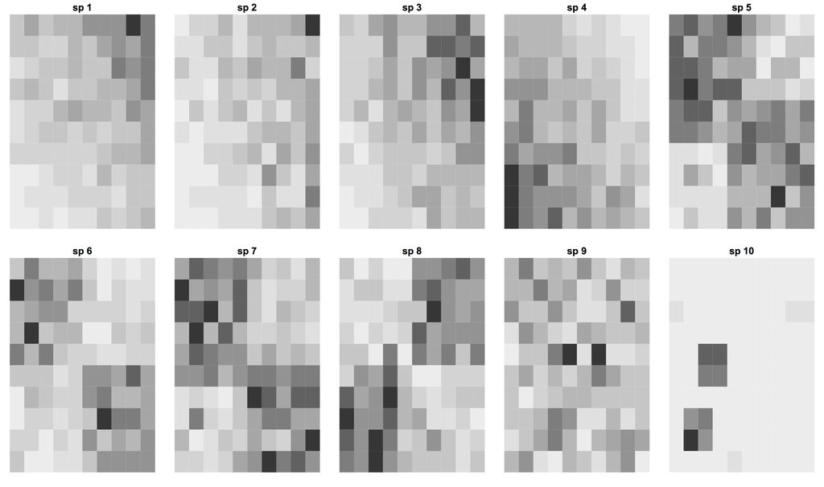

Você percebe padrões nos mapas acima? Se há padrão, queremos uma explicação! Imagine que você tenha também mapas de medidas de cinco variáveis de solo importantes para as plantas, em cada quadrícula :

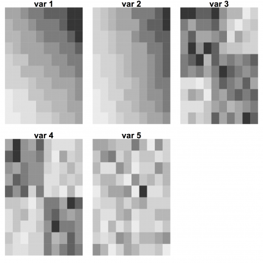

Parece haver relação entre os dois mapas? O objetivo da particão da variação é avaliar essas relações. Ou seja, estabelecer relações entre padrões espaciais das espécies, e destas com outras variáveis do ambiente. Feito isso, é possível quantificar quanto da variação de abundância das espécies foi captada, ou explicada, pelas variáveis ambientais.

## Particão passo a passo

A partição da variação pode ser aplicada para cada espécie separadamente ou para a comunidade como um todo. Nesta prática, vamos começar entendendo e aplicando a técnica de partição da variação para apenas uma espécie e depois vamos aprender como generalizar a análise para a comunidade, utilizando técnicas de **Análises Multivariadas**.

Para fazer a prática, siga os seguintes roteiros:

- Coeficiente de determinação, o conceito que está na base da partição de variação;
- Partição de variação com uma espécie, em que a ideia é apresentada para o caso mais simples de uma espécie e uma variável preditora por vez.
- Particão de variação multivariada, que mostra como a análise pode ser feita para dados de muitas espécies e muitas variáveis preditoras de uma vez.